# DATA624-HW6-ARIMA

### c) Write your own code to generate data from an MA(1) model with $\theta_1=0.6$ and $\sigma^2=1$.

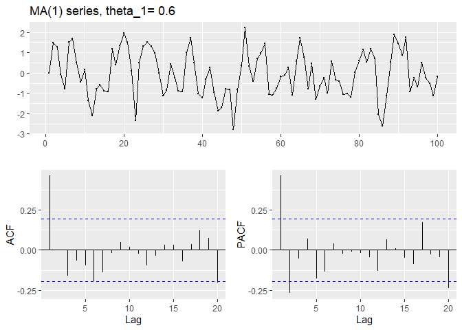

```r
MA1 <- function(theta_1)
{
  y <- ts(numeric(100))
  e <- rnorm(100)
  for(i in 2:100)
    y[i] <- e[i] + theta_1*e[i-1]
  return(y)
}

theta_1 <- 0.60
ggtsdisplay(MA1(theta_1),main=paste("MA(1) series, theta_1=",theta_1))
```

### d) Produce a time plot for the series. How does the plot change as you change $\theta_1$ ?

```r
set.seed(12345)
MA1_stats_results = numeric()
theta_seq <- seq(from=-1,to=1,by = 0.1)

for (theta_1 in theta_seq) {
  MA1_series <- MA1(theta_1)
  MA1_stats <- c(theta_1 = theta_1, summary(MA1_series),StDev=sd(MA1_series),SdDiff=sd(diff(MA1_series)))
  MA1_main <- paste("MA(1) series, theta_1=",theta_1)
  ggtsdisplay(MA1_series,main=MA1_main)
  #print(MA1_stats)
  MA1_stats_results <- rbind(MA1_stats_results,MA1_stats)
}
```

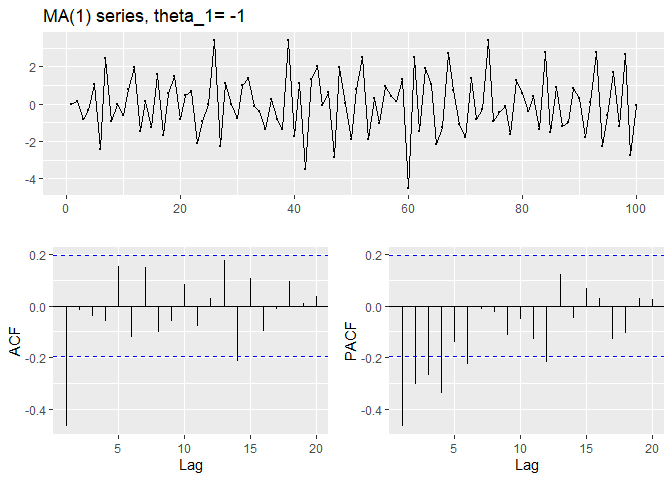

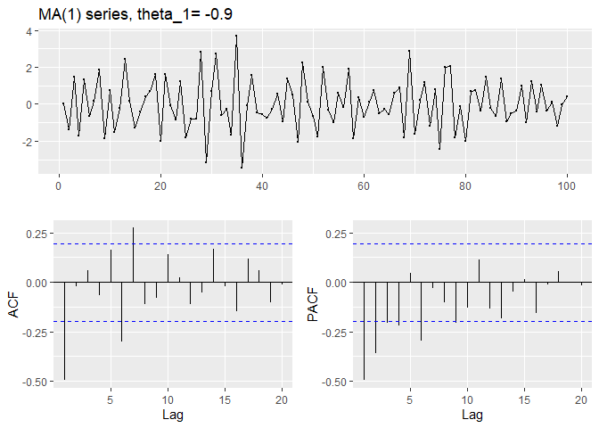

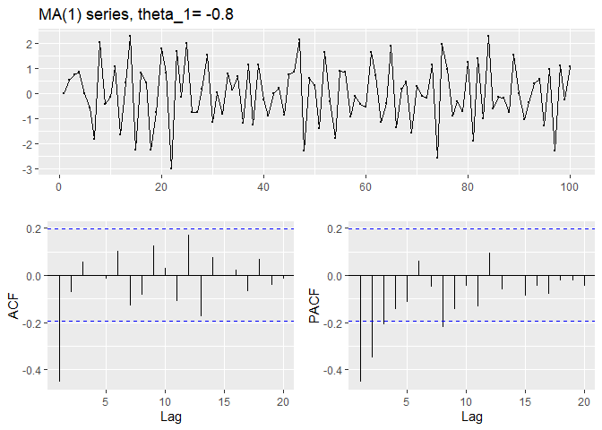

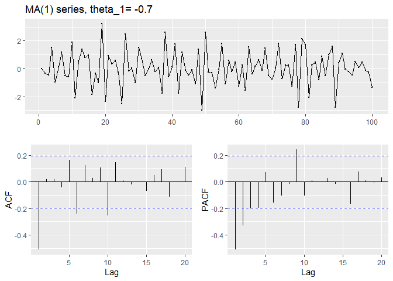

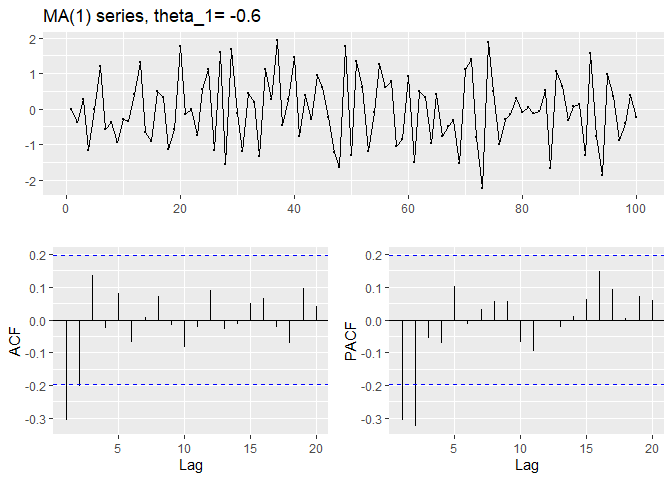

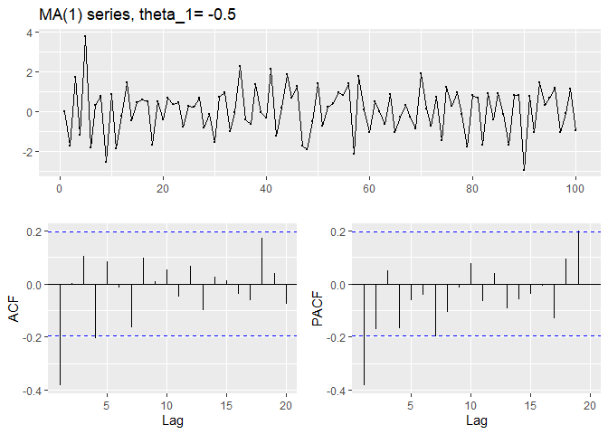

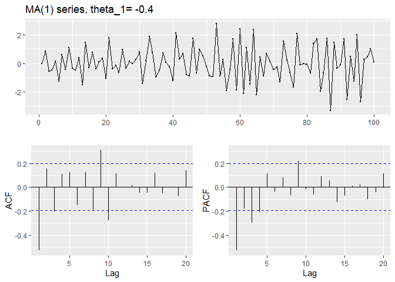

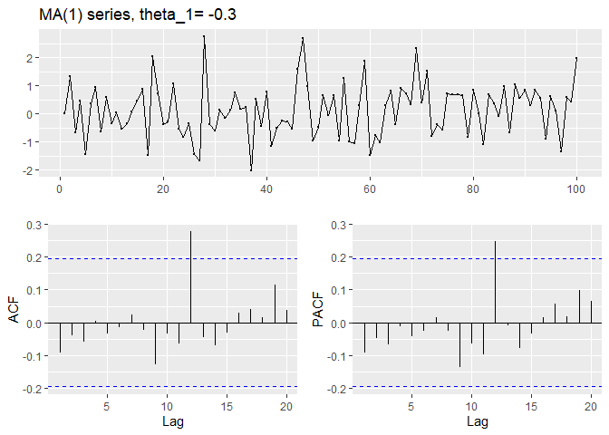

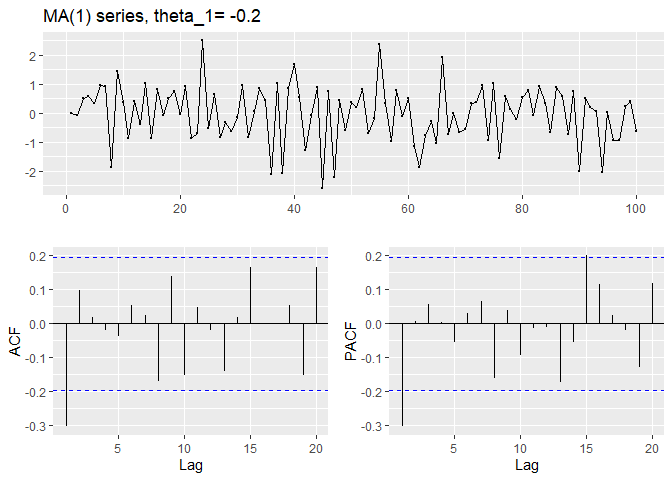

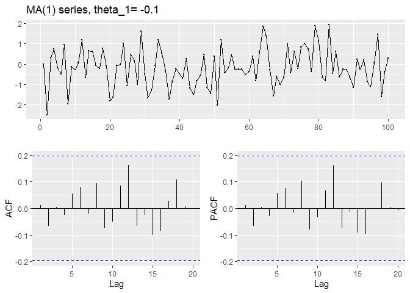

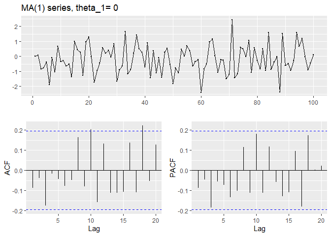

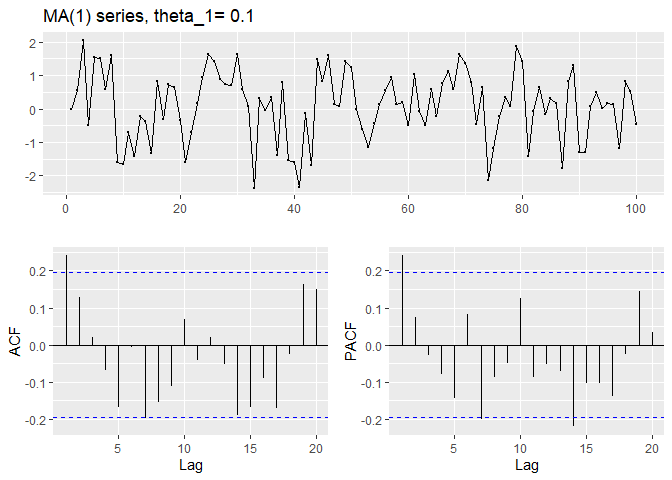

[9 more figures not shown]

```r
MA1_stats_results
```

```
##           theta_1      Min.    1st Qu.       Median         Mean   3rd Qu.
## MA1_stats    -1.0 -4.492009 -1.1930459 -0.008115974 -0.012800755 1.0423410
## MA1_stats    -0.9 -3.438123 -0.8186108 -0.149618065  0.002403803 0.8154866
## MA1_stats    -0.8 -2.984302 -0.7811010 -0.011340950  0.008833616 0.8580352
## MA1_stats    -0.7 -2.963578 -0.5265045  0.004962544  0.049736692 0.8252867
## MA1_stats    -0.6 -2.219001 -0.7707898 -0.073540232 -0.027025561 0.5586403
## MA1_stats    -0.5 -2.956448 -0.7615168  0.202943008  0.044074542 0.8134004
## MA1_stats    -0.4 -3.299380 -0.6885207 -0.015867014  0.015052916 0.7564226
## MA1_stats    -0.3 -2.003957 -0.5314231  0.146578293  0.131302994 0.7055644
## MA1_stats    -0.2 -2.576290 -0.7096066  0.099984501 -0.011679411 0.6775915
## MA1_stats    -0.1 -2.481566 -0.6759008 -0.236799542 -0.168755851 0.4768884
## MA1_stats     0.0 -2.402710 -0.8855039 -0.268306656 -0.201570142 0.4703282
## MA1_stats     0.1 -2.363203 -0.4754717  0.151771071  0.098824380 0.8094831
## MA1_stats     0.2 -2.274544 -0.6830629  0.078845990 -0.028625444 0.7674243
## MA1_stats     0.3 -3.415573 -0.9011877 -0.258412367 -0.260718447 0.3876916
## MA1_stats     0.4 -3.381696 -0.4779428  0.080985451  0.163468653 0.7187999
## MA1_stats     0.5 -2.558856 -1.1446726 -0.146720887 -0.104500453 0.6942808
## MA1_stats     0.6 -3.771141 -0.8557957 -0.146433616 -0.056425331 0.6323674
## MA1_stats     0.7 -4.279108 -0.4368935  0.044567422  0.019592689 0.7057627
## MA1_stats     0.8 -3.745527 -0.9768702 -0.113807449 -0.125918865 0.7216140
## MA1_stats     0.9 -4.245927 -0.6990842  0.261715767  0.150833884 1.0473766
## MA1_stats     1.0 -3.493543 -1.1611192 -0.012198327 -0.123620590 0.8122150
##               Max.     StDev   SdDiff
## MA1_stats 3.429784 1.5925282 2.743818
## MA1_stats 3.721981 1.3723823 2.386705
## MA1_stats 2.291511 1.1963768 2.047869
## MA1_stats 3.252309 1.2505515 2.180980
## MA1_stats 1.944725 0.9574078 1.554551
## MA1_stats 3.799719 1.1727331 1.957892
## MA1_stats 2.811955 1.2130408 2.134068
## MA1_stats 2.757477 0.9479098 1.396446
## MA1_stats 2.532845 0.9858267 1.598275
## MA1_stats 1.949466 0.9234721 1.303728
## MA1_stats 2.457074 0.9453084 1.400122
## MA1_stats 2.067448 1.0355752 1.281394
## MA1_stats 2.500290 1.0225437 1.272520
## MA1_stats 1.625555 1.0126370 1.303601
## MA1_stats 3.910220 1.1069485 1.186168
## MA1_stats 2.407064 1.1852027 1.301631
## MA1_stats 3.471755 1.2484914 1.253210
## MA1_stats 2.893791 1.2448962 1.329048
## MA1_stats 2.472278 1.2125560 1.258386
## MA1_stats 3.761269 1.4816009 1.518935
## MA1_stats 2.505968 1.3471470 1.426041
```

- The ACF for the MA(1) model shows zero correlation after the first lag (i.e.,the subsequent lags generally fall within the critical bounds.
- The MA(1) model remains stationary regardless of the value of $\theta_1$.
- The change in the value of $\theta_1$ determines the importance of the random shock from the previous period relative to that of the current period.

### e) Generate data from an ARMA(1,1) model with

$\phi_1=0.6$, $\theta_1=0.6$, and $\sigma^2=1$.

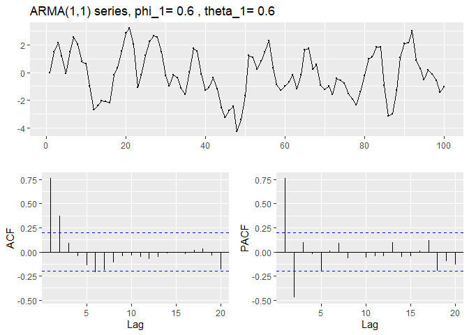

```r
ARMA_1_1 <- function(phi_1, theta_1)
{
  y <- ts(numeric(100))
  e <- rnorm(100)
  for(i in 2:100)
    y[i] <- phi_1*y[i-1] + theta_1*e[i-1] + e[i]
  return(y)
}
phi_1 <- 0.60
theta_1 <- 0.60
ARMA_1_1_result <- ARMA_1_1(phi_1,theta_1)
ggtsdisplay(ARMA_1_1_result,main=paste("ARMA(1,1) series, phi_1=", phi_1, ", theta_1=",theta_1))
```

### f) Generate data from an AR(2) model with $\phi_1=-0.8$, $\phi_2=0.3$, and $\sigma^2=1$.

(Note that these parameters will give a **non-stationary** series.)

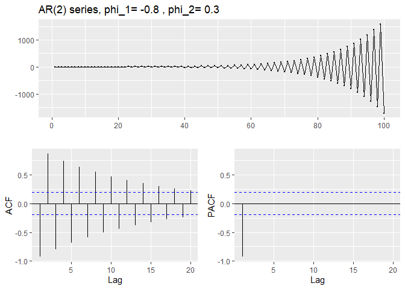

```r
AR2 <- function(phi_1, phi_2)
{
  y <- ts(numeric(100))
  e <- rnorm(100)
  for(i in 3:100)
    y[i] <- phi_1*y[i-1] + phi_2*y[i-2] + e[i]
  return(y)
}

phi_1 <- -0.80
phi_2 <-  0.30
AR2_result <- AR2(phi_1,phi_2)
ggtsdisplay(AR2_result,main=paste("AR(2) series, phi_1=", phi_1, ", phi_2=",phi_2))
```

### g) Graph the latter two series and compare them.

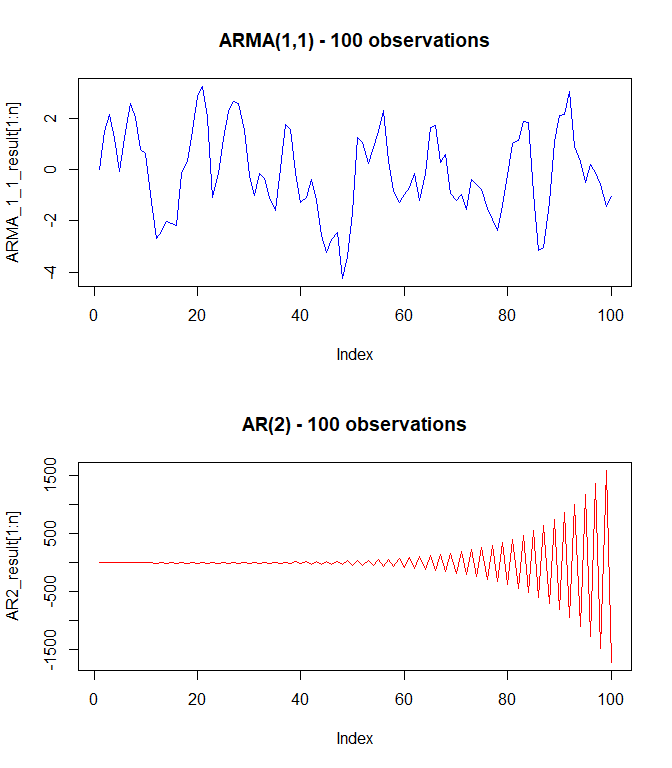

```r
n=100
par(mfrow=c(2,1))
plot(ARMA_1_1_result[1:n], type="l", main="ARMA(1,1) - 100 observations",col="blue")
plot(AR2_result[1:n], type="l", main="AR(2) - 100 observations",col="red")
```

While it may appear that this series initially remains very close to zero, the difference in the Y-axes masks this behavior for the AR(2) series.

By plotting just the earlier portion of the two series, it is easier to see their behavior:

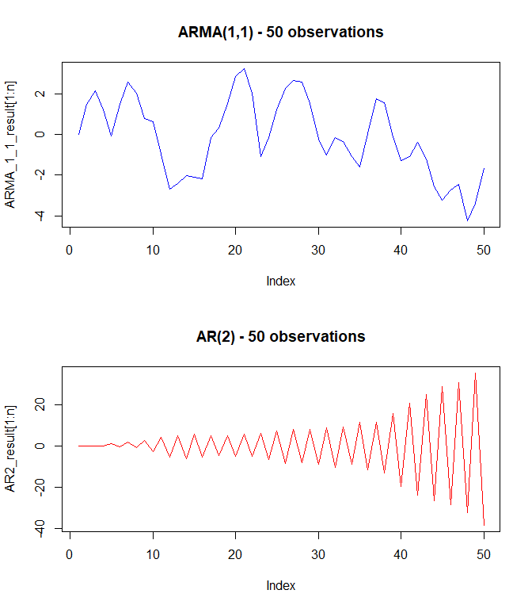

```r
n=50
par(mfrow=c(2,1))
plot(ARMA_1_1_result[1:n], type="l", main="ARMA(1,1) - 50 observations",col="blue")
plot(AR2_result[1:n], type="l", main="AR(2) - 50 observations",col="red")
```

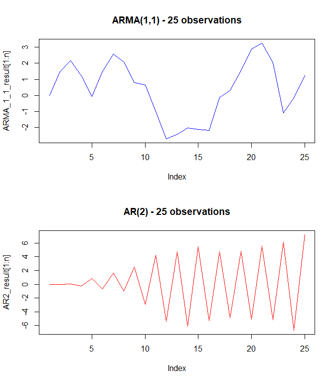

```r
n=25
par(mfrow=c(2,1))
plot(ARMA_1_1_result[1:n], type="l", main="ARMA(1,1) - 25 observations",col="blue")
plot(AR2_result[1:n], type="l", main="AR(2) - 25 observations",col="red")
```

## 8.7 Consider `wmurders`, the number of women murdered each year (per 100,000 standard population) in the United States.

### a) By studying appropriate graphs of the series in R, find an appropriate ARIMA(p,d,q) model for these data.

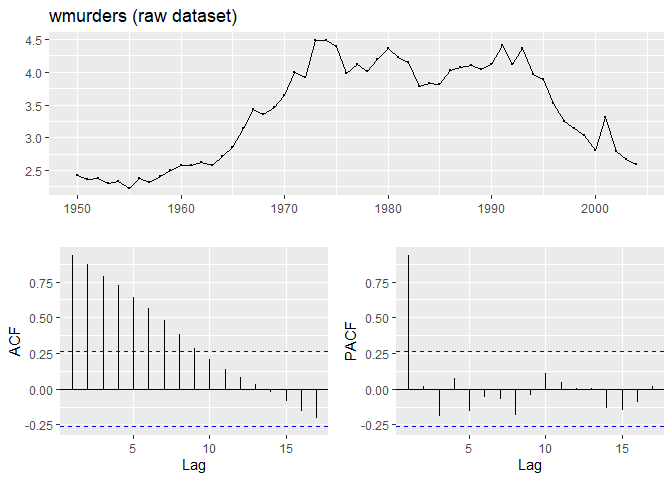

```r
wmurders %>% ggtsdisplay(main="wmurders (raw dataset)")
```

#### There is a pattern in the ACF function, and a spike in the PACF function.

#### Check KPSS:

#### Kwiatkowski-Phillips-Schmidt-Shin (KPSS) test:

```r
library(tseries)

#### Test raw data series
kpss.test(wmurders, "Level", lshort = F)
```

```
##
##  KPSS Test for Level Stationarity
##
## data:  wmurders
## KPSS Level = 0.28623, Truncation lag parameter = 10, p-value = 0.1
```

```r
kpss.test(wmurders, "Trend", lshort = F)
```

```
##
##  KPSS Test for Trend Stationarity
##
## data:  wmurders
## KPSS Trend = 0.1591, Truncation lag parameter = 10, p-value = 0.03909
```

```r
wmurders %>% ur.kpss(type="mu", lags="long") %>% summary()
```

```
##
## #######################
## # KPSS Unit Root Test #
## #######################
##
## Test is of type: mu with 10 lags.
##
## Value of test-statistic is: 0.2862
##
## Critical value for a significance level of:
##                 10pct  5pct 2.5pct  1pct
## critical values 0.347 0.463  0.574 0.739
```

```r
wmurders %>% ur.kpss(type="tau", lags="long") %>% summary()
```

```
##
## #######################
## # KPSS Unit Root Test #
## #######################
##
## Test is of type: tau with 10 lags.
##
## Value of test-statistic is: 0.1591
##
## Critical value for a significance level of:
##                 10pct  5pct 2.5pct  1pct
## critical values 0.119 0.146  0.176 0.216
```

Level passes, but Trend fails.

#### Check ndiffs:

```r
ndiffs(wmurders)
```

```
## [1] 2
```

#### ndiffs indicates that we will need 2 differences.

#### check first differences

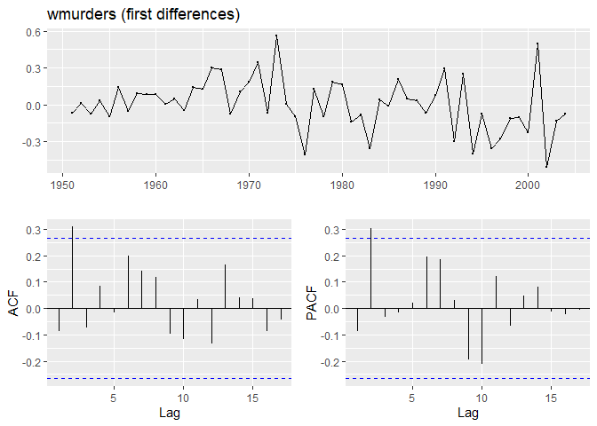

```r
wmurders_d1 <- wmurders %>% diff()
wmurders_d1 %>% ggtsdisplay(main="wmurders (first differences)")
```

#### There are still spikes at the second lag.

#### Check KPSS:

```r
#### Test first differences
kpss.test(wmurders_d1, "Level", lshort = F)
```

```
##
##  KPSS Test for Level Stationarity
##
## data:  wmurders_d1
## KPSS Level = 0.33134, Truncation lag parameter = 10, p-value = 0.1
```

```r
kpss.test(wmurders_d1, "Trend", lshort = F)
```

```
##
##  KPSS Test for Trend Stationarity
##
## data:  wmurders_d1
## KPSS Trend = 0.11631, Truncation lag parameter = 10, p-value = 0.1
```

```r
wmurders_d1 %>% ur.kpss(type="mu", lags="long") %>% summary()
```

```
##
## #######################
## # KPSS Unit Root Test #
## #######################
##
## Test is of type: mu with 10 lags.
##
## Value of test-statistic is: 0.3313
##
## Critical value for a significance level of:
##                 10pct  5pct 2.5pct  1pct
## critical values 0.347 0.463  0.574 0.739
```

```r
wmurders_d1 %>% ur.kpss(type="tau", lags="long") %>% summary()
```

```
##
## #######################
## # KPSS Unit Root Test #
## #######################
##
## Test is of type: tau with 10 lags.
##
## Value of test-statistic is: 0.1163
##
## Critical value for a significance level of:
##                 10pct  5pct 2.5pct  1pct
## critical values 0.119 0.146  0.176 0.216
```

The tests pass, but why did ndiffs return 2?

#### Look at second differences

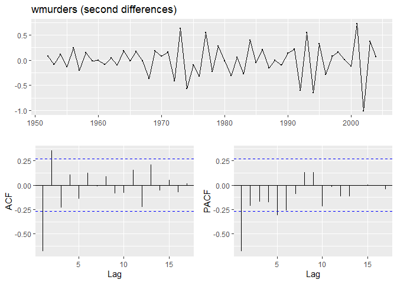

```r
wmurders_d2 <- wmurders_d1 %>% diff()
wmurders_d2 %>% ggtsdisplay(main="wmurders (second differences)")
```

This looks even worse…

#### Check KPSS:

```r
#### Test second differences
kpss.test(wmurders_d2, "Level", lshort = F)
```

```
##
##  KPSS Test for Level Stationarity
##
## data:  wmurders_d2
## KPSS Level = 0.12299, Truncation lag parameter = 10, p-value = 0.1
```

```r
kpss.test(wmurders_d2, "Trend", lshort = F)
```

```
##
##  KPSS Test for Trend Stationarity
##
## data:  wmurders_d2
## KPSS Trend = 0.10938, Truncation lag parameter = 10, p-value = 0.1
```

```r
wmurders_d2 %>% ur.kpss(type="mu", lags="long") %>% summary()
```

```
##
## #######################
## # KPSS Unit Root Test #
## #######################
##
## Test is of type: mu with 10 lags.
##
## Value of test-statistic is: 0.123
##
## Critical value for a significance level of:
##                 10pct  5pct 2.5pct  1pct
## critical values 0.347 0.463  0.574 0.739
```

```r
wmurders_d2 %>% ur.kpss(type="tau", lags="long") %>% summary()
```

```
##
## #######################
## # KPSS Unit Root Test #
## #######################
##
## Test is of type: tau with 10 lags.
##
## Value of test-statistic is: 0.1094
##
## Critical value for a significance level of:
##                 10pct  5pct 2.5pct  1pct
## critical values 0.119 0.146  0.176 0.216
```

This passes, too, but it’s unclear why we need the second difference.

Let’s assume the model is ARIMA(p,2,q).

Because of the spikes in the ACF and the PACF at lag=1, the model may be ARIMA(1,2,0) or ARIMA(0,2,1).

Alternatively, it might be ARIMA(1,2,1), but the text indicates that you can’t determine both (p,q) nonzero from looking at the graphs. However, auto.arima indicates that it should be ARIMA(1,2,1), so let’s use that.

### b) Should you include a constant in the model? Explain.

No, because a constant would cause a drift, and there is no drift visible in the data.

### c) Write this model in terms of the backshift operator.

In general, ARIMA(1,2,1): $(1-\phi_1B) (1-B)^2 y_{t} = c + (1 + \theta_1 B )\varepsilon_t$, but we have decided to omit the constant, so $(1-\phi_1B) (1-B)^2 y_{t} = (1 + \theta_1 B )\varepsilon_t$

### d) Fit the model using R and examine the residuals. Is the model satisfactory?

```r
(wmurders_fit <- Arima(wmurders, c(1,2,1)))
```

```
## Series: wmurders
## ARIMA(1,2,1)
##
## Coefficients:
##           ar1      ma1
##       -0.2434  -0.8261
## s.e.   0.1553   0.1143
##
## sigma^2 estimated as 0.04632:  log likelihood=6.44
## AIC=-6.88   AICc=-6.39   BIC=-0.97
```

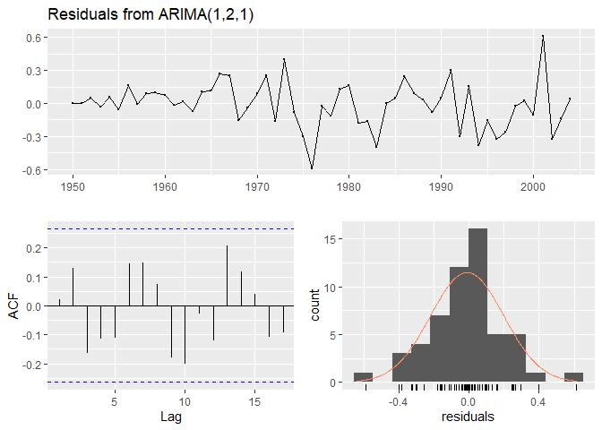

```
##
##  Ljung-Box test
##
## data:  Residuals from ARIMA(1,2,1)
## Q* = 12.419, df = 8, p-value = 0.1335
##
## Model df: 2.   Total lags used: 10
```

```r
checkresiduals(wmurders_fit)
```

Because the p-value is high, we FAIL TO REJECT the null hypothesis, which is that the data are independent (i.e., no serial correlation.)

Additionally, the ACF bars all fall within the critical bands.

Therefore, the model is satisfactory.

### e) Forecast three times ahead. Check your forecasts by hand to make sure that you know how they have been calculated.

```r
wmurders_forecast <- forecast(wmurders_fit, h = 3)
wmurders_forecast
```

```
##      Point Forecast    Lo 80    Hi 80    Lo 95    Hi 95
## 2005       2.470660 2.194836 2.746484 2.048824 2.892496
## 2006       2.363106 1.986351 2.739862 1.786908 2.939304
## 2007       2.252833 1.765391 2.740276 1.507354 2.998313
```

### f) Create a plot of the series with forecasts and prediction intervals for the next three periods shown.

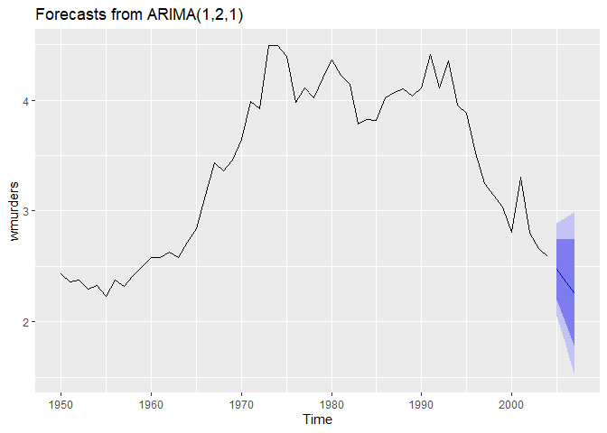

```r
autoplot(wmurders_forecast)
```

### g) Does `auto.arima()` give the same model you have chosen? If not, which model do you think is better?

```r
wmurders_fit_autoarima <- auto.arima(wmurders)
wmurders_fit_autoarima
```

```
## Series: wmurders
## ARIMA(1,2,1)
##
## Coefficients:
##           ar1      ma1
##       -0.2434  -0.8261
## s.e.   0.1553   0.1143
##
## sigma^2 estimated as 0.04632:  log likelihood=6.44
## AIC=-6.88   AICc=-6.39   BIC=-0.97
```

```r
wmurders_forecast_autoarima <- forecast(wmurders_fit_autoarima, h = 3)
wmurders_forecast_autoarima
```

```
##      Point Forecast    Lo 80    Hi 80    Lo 95    Hi 95
## 2005       2.470660 2.194836 2.746484 2.048824 2.892496
## 2006       2.363106 1.986351 2.739862 1.786908 2.939304
## 2007       2.252833 1.765391 2.740276 1.507354 2.998313
```

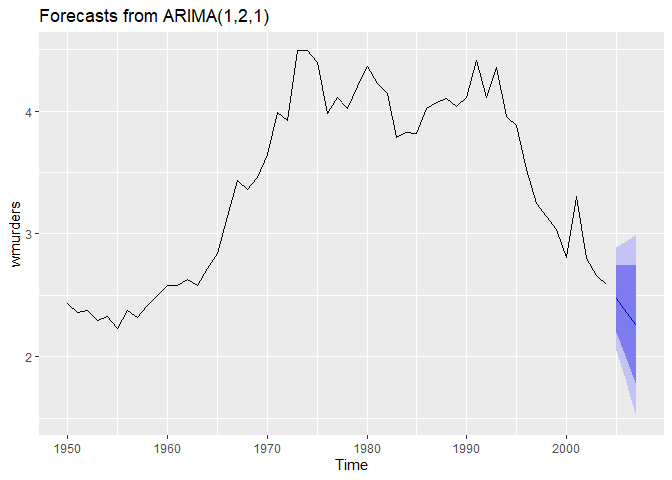

```r
autoplot(wmurders_forecast_autoarima)
```

The model selected is the same.